# Risk Factor Analysis

## Outcome Variable

**Outcome Variable:** wasted

## Predictor Variables

**Intervention Variable:** mhtcm

**Adjustment Set:**

- arm
- W_mage
- meducyrs
- feducyrs
- single
- delta_W_mage
- delta_meducyrs
- delta_feducyrs
- delta_single

## Stratifying Variables

The analysis was stratified on these variable(s):

- agecat
- studyid
- country

## Data Summary

| agecat | studyid | country | mhtcm | wasted | n_cell | n |
| --- | --- | --- | --- | --- | --- | --- |
| Birth | ki0047075b-MAL-ED | BANGLADESH | >=155 cm | 0 | 21 | 233 |
| Birth | ki0047075b-MAL-ED | BANGLADESH | >=155 cm | 1 | 3 | 233 |
| Birth | ki0047075b-MAL-ED | BANGLADESH | <151 cm | 0 | 121 | 233 |
| Birth | ki0047075b-MAL-ED | BANGLADESH | <151 cm | 1 | 24 | 233 |
| Birth | ki0047075b-MAL-ED | BANGLADESH | [151-155) cm | 0 | 52 | 233 |
| Birth | ki0047075b-MAL-ED | BANGLADESH | [151-155) cm | 1 | 12 | 233 |
| Birth | ki0047075b-MAL-ED | BRAZIL | >=155 cm | 0 | 101 | 176 |
| Birth | ki0047075b-MAL-ED | BRAZIL | >=155 cm | 1 | 4 | 176 |
| Birth | ki0047075b-MAL-ED | BRAZIL | <151 cm | 0 | 44 | 176 |
| Birth | ki0047075b-MAL-ED | BRAZIL | <151 cm | 1 | 2 | 176 |
| Birth | ki0047075b-MAL-ED | BRAZIL | [151-155) cm | 0 | 25 | 176 |
| Birth | ki0047075b-MAL-ED | BRAZIL | [151-155) cm | 1 | 0 | 176 |
| Birth | ki0047075b-MAL-ED | INDIA | >=155 cm | 0 | 38 | 195 |
| Birth | ki0047075b-MAL-ED | INDIA | >=155 cm | 1 | 7 | 195 |
| Birth | ki0047075b-MAL-ED | INDIA | <151 cm | 0 | 77 | 195 |
| Birth | ki0047075b-MAL-ED | INDIA | <151 cm | 1 | 17 | 195 |
| Birth | ki0047075b-MAL-ED | INDIA | [151-155) cm | 0 | 48 | 195 |
| Birth | ki0047075b-MAL-ED | INDIA | [151-155) cm | 1 | 8 | 195 |
| Birth | ki0047075b-MAL-ED | NEPAL | >=155 cm | 0 | 25 | 167 |
| Birth | ki0047075b-MAL-ED | NEPAL | >=155 cm | 1 | 2 | 167 |
| Birth | ki0047075b-MAL-ED | NEPAL | <151 cm | 0 | 81 | 167 |
| Birth | ki0047075b-MAL-ED | NEPAL | <151 cm | 1 | 12 | 167 |
| Birth | ki0047075b-MAL-ED | NEPAL | [151-155) cm | 0 | 41 | 167 |
| Birth | ki0047075b-MAL-ED | NEPAL | [151-155) cm | 1 | 6 | 167 |
| Birth | ki0047075b-MAL-ED | PERU | >=155 cm | 0 | 55 | 269 |
| Birth | ki0047075b-MAL-ED | PERU | >=155 cm | 1 | 1 | 269 |
| Birth | ki0047075b-MAL-ED | PERU | <151 cm | 0 | 152 | 269 |
| Birth | ki0047075b-MAL-ED | PERU | <151 cm | 1 | 4 | 269 |
| Birth | ki0047075b-MAL-ED | PERU | [151-155) cm | 0 | 56 | 269 |
| Birth | ki0047075b-MAL-ED | PERU | [151-155) cm | 1 | 1 | 269 |

[output cut: 318 more lines]

The following strata were considered:

- agecat: 24 months, studyid: ki0047075b-MAL-ED, country: BANGLADESH
- agecat: 24 months, studyid: ki0047075b-MAL-ED, country: BRAZIL
- agecat: 24 months, studyid: ki0047075b-MAL-ED, country: INDIA
- agecat: 24 months, studyid: ki0047075b-MAL-ED, country: NEPAL
- agecat: 24 months, studyid: ki0047075b-MAL-ED, country: PERU
- agecat: 24 months, studyid: ki0047075b-MAL-ED, country: SOUTH AFRICA
- agecat: 24 months, studyid: ki0047075b-MAL-ED, country: TANZANIA, UNITED REPUBLIC OF
- agecat: 24 months, studyid: ki1017093-NIH-Birth, country: BANGLADESH
- agecat: 24 months, studyid: ki1017093b-PROVIDE, country: BANGLADESH
- agecat: 24 months, studyid: ki1017093c-NIH-Crypto, country: BANGLADESH
- agecat: 24 months, studyid: ki1066203-TanzaniaChild2, country: TANZANIA, UNITED REPUBLIC OF
- agecat: 24 months, studyid: ki1101329-Keneba, country: GAMBIA
- agecat: 24 months, studyid: ki1119695-PROBIT, country: BELARUS
- agecat: 24 months, studyid: ki1126311-ZVITAMBO, country: ZIMBABWE
- agecat: 24 months, studyid: ki1135781-COHORTS, country: GUATEMALA
- agecat: 24 months, studyid: ki1135781-COHORTS, country: INDIA
- agecat: 24 months, studyid: ki1135781-COHORTS, country: PHILIPPINES
- agecat: 24 months, studyid: ki1148112-LCNI-5, country: MALAWI
- agecat: 24 months, studyid: kiGH5241-JiVitA-3, country: BANGLADESH
- agecat: 6 months, studyid: ki0047075b-MAL-ED, country: BANGLADESH
- agecat: 6 months, studyid: ki0047075b-MAL-ED, country: BRAZIL
- agecat: 6 months, studyid: ki0047075b-MAL-ED, country: INDIA
- agecat: 6 months, studyid: ki0047075b-MAL-ED, country: NEPAL
- agecat: 6 months, studyid: ki0047075b-MAL-ED, country: PERU
- agecat: 6 months, studyid: ki0047075b-MAL-ED, country: SOUTH AFRICA
- agecat: 6 months, studyid: ki0047075b-MAL-ED, country: TANZANIA, UNITED REPUBLIC OF
- agecat: 6 months, studyid: ki1000304b-SAS-CompFeed, country: INDIA
- agecat: 6 months, studyid: ki1000304b-SAS-FoodSuppl, country: INDIA
- agecat: 6 months, studyid: ki1017093-NIH-Birth, country: BANGLADESH
- agecat: 6 months, studyid: ki1017093b-PROVIDE, country: BANGLADESH
- agecat: 6 months, studyid: ki1017093c-NIH-Crypto, country: BANGLADESH
- agecat: 6 months, studyid: ki1066203-TanzaniaChild2, country: TANZANIA, UNITED REPUBLIC OF
- agecat: 6 months, studyid: ki1101329-Keneba, country: GAMBIA
- agecat: 6 months, studyid: ki1112895-Guatemala BSC, country: GUATEMALA
- agecat: 6 months, studyid: ki1119695-PROBIT, country: BELARUS
- agecat: 6 months, studyid: ki1126311-ZVITAMBO, country: ZIMBABWE
- agecat: 6 months, studyid: ki1135781-COHORTS, country: GUATEMALA
- agecat: 6 months, studyid: ki1135781-COHORTS, country: INDIA
- agecat: 6 months, studyid: ki1135781-COHORTS, country: PHILIPPINES
- agecat: 6 months, studyid: ki1148112-LCNI-5, country: MALAWI
- agecat: 6 months, studyid: kiGH5241-JiVitA-3, country: BANGLADESH
- agecat: Birth, studyid: ki0047075b-MAL-ED, country: BANGLADESH
- agecat: Birth, studyid: ki0047075b-MAL-ED, country: BRAZIL
- agecat: Birth, studyid: ki0047075b-MAL-ED, country: INDIA
- agecat: Birth, studyid: ki0047075b-MAL-ED, country: NEPAL
- agecat: Birth, studyid: ki0047075b-MAL-ED, country: PERU
- agecat: Birth, studyid: ki0047075b-MAL-ED, country: SOUTH AFRICA
- agecat: Birth, studyid: ki0047075b-MAL-ED, country: TANZANIA, UNITED REPUBLIC OF
- agecat: Birth, studyid: ki1000304b-SAS-CompFeed, country: INDIA
- agecat: Birth, studyid: ki1017093-NIH-Birth, country: BANGLADESH
- agecat: Birth, studyid: ki1017093c-NIH-Crypto, country: BANGLADESH
- agecat: Birth, studyid: ki1101329-Keneba, country: GAMBIA
- agecat: Birth, studyid: ki1119695-PROBIT, country: BELARUS
- agecat: Birth, studyid: ki1126311-ZVITAMBO, country: ZIMBABWE
- agecat: Birth, studyid: ki1135781-COHORTS, country: GUATEMALA
- agecat: Birth, studyid: ki1135781-COHORTS, country: INDIA
- agecat: Birth, studyid: ki1135781-COHORTS, country: PHILIPPINES
- agecat: Birth, studyid: kiGH5241-JiVitA-3, country: BANGLADESH

### Dropped Strata

Some strata were dropped due to rare outcomes:

- agecat: Birth, studyid: ki0047075b-MAL-ED, country: BANGLADESH
- agecat: Birth, studyid: ki0047075b-MAL-ED, country: BRAZIL
- agecat: Birth, studyid: ki0047075b-MAL-ED, country: NEPAL
- agecat: Birth, studyid: ki0047075b-MAL-ED, country: PERU
- agecat: Birth, studyid: ki0047075b-MAL-ED, country: SOUTH AFRICA
- agecat: Birth, studyid: ki0047075b-MAL-ED, country: TANZANIA, UNITED REPUBLIC OF
- agecat: Birth, studyid: ki1000304b-SAS-CompFeed, country: INDIA
- agecat: Birth, studyid: ki1017093-NIH-Birth, country: BANGLADESH
- agecat: Birth, studyid: ki1017093c-NIH-Crypto, country: BANGLADESH
- agecat: Birth, studyid: ki1101329-Keneba, country: GAMBIA
- agecat: 6 months, studyid: ki0047075b-MAL-ED, country: BANGLADESH
- agecat: 6 months, studyid: ki0047075b-MAL-ED, country: BRAZIL
- agecat: 6 months, studyid: ki0047075b-MAL-ED, country: INDIA
- agecat: 6 months, studyid: ki0047075b-MAL-ED, country: NEPAL
- agecat: 6 months, studyid: ki0047075b-MAL-ED, country: PERU
- agecat: 6 months, studyid: ki0047075b-MAL-ED, country: SOUTH AFRICA
- agecat: 6 months, studyid: ki0047075b-MAL-ED, country: TANZANIA, UNITED REPUBLIC OF
- agecat: 6 months, studyid: ki1017093c-NIH-Crypto, country: BANGLADESH
- agecat: 6 months, studyid: ki1112895-Guatemala BSC, country: GUATEMALA
- agecat: 6 months, studyid: ki1119695-PROBIT, country: BELARUS
- agecat: 6 months, studyid: ki1135781-COHORTS, country: GUATEMALA
- agecat: 6 months, studyid: ki1148112-LCNI-5, country: MALAWI
- agecat: 24 months, studyid: ki0047075b-MAL-ED, country: BANGLADESH
- agecat: 24 months, studyid: ki0047075b-MAL-ED, country: BRAZIL
- agecat: 24 months, studyid: ki0047075b-MAL-ED, country: INDIA
- agecat: 24 months, studyid: ki0047075b-MAL-ED, country: NEPAL
- agecat: 24 months, studyid: ki0047075b-MAL-ED, country: PERU
- agecat: 24 months, studyid: ki0047075b-MAL-ED, country: SOUTH AFRICA
- agecat: 24 months, studyid: ki0047075b-MAL-ED, country: TANZANIA, UNITED REPUBLIC OF
- agecat: 24 months, studyid: ki1066203-TanzaniaChild2, country: TANZANIA, UNITED REPUBLIC OF
- agecat: 24 months, studyid: ki1119695-PROBIT, country: BELARUS
- agecat: 24 months, studyid: ki1148112-LCNI-5, country: MALAWI

## Methods Detail

We’re interested in the causal parameters $E[Y_a]$ for all values of $a \in \mathcal{A}$. These parameters represent the mean outcome if, possibly contrary to fact, we intervened to set all units to have $A=a$. Under the randomization and positivity assumptions, these are identified by the statistical parameters $\psi_a=E_W[E_{Y|A,W}(Y|A=a,W)]$. In addition, we’re interested in the mean of $Y$, $E[Y]$ under no intervention (the observed mean). We will estimate these parameters by using SuperLearner to fit the relevant likelihood factors – $E_{Y|A,W}(Y|A=a,W)$ and $p(A=a|W)$, and then updating our likelihood fit using a joint TMLE.

For unadjusted analyses ($W=\{\}$), initial likelihoods were estimated using Lrnr_glm to estimate the simple $E(Y|A)$ and Lrnr_mean to estimate $p(A)$. For adjusted analyses, a small library containing Lrnr_glmnet, Lrnr_xgboost, and Lrnr_mean was used.

Having estimated these parameters, we will then use the delta method to estimate relative risks and attributable risks relative to a prespecified baseline level of $A$.

# Results Detail

## Results Plots

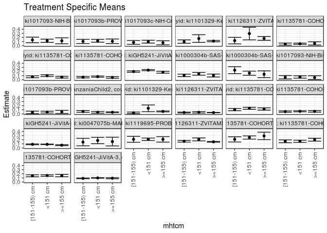

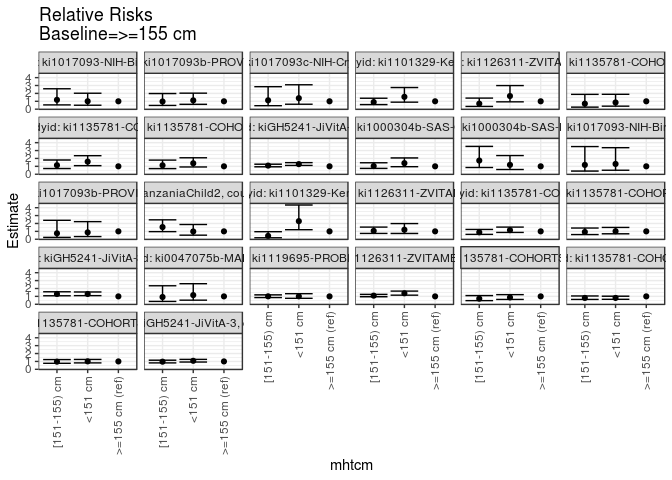

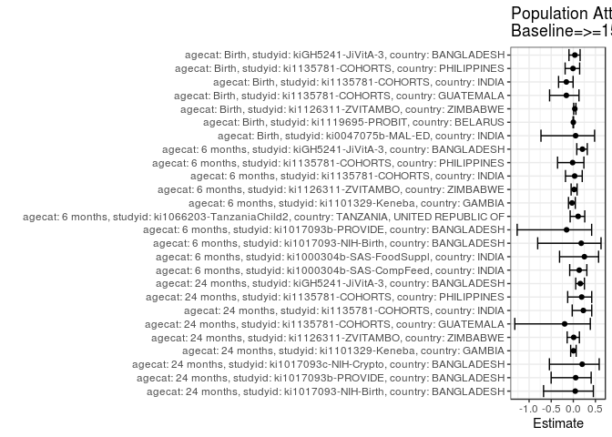

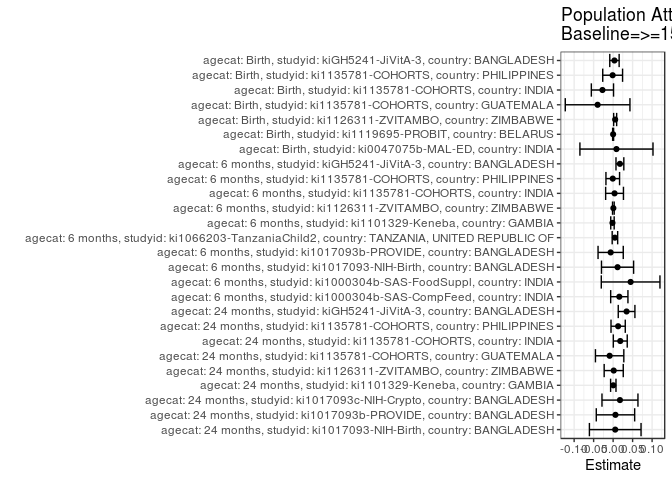

## Results Table

### Parameter: TSM

| agecat | studyid | country | intervention_level | baseline_level | estimate | ci_lower | ci_upper |
| --- | --- | --- | --- | --- | --- | --- | --- |
| Birth | ki0047075b-MAL-ED | INDIA | >=155 cm | NA | 0.1555556 | 0.0493893 | 0.2617218 |
| Birth | ki0047075b-MAL-ED | INDIA | <151 cm | NA | 0.1808511 | 0.1028424 | 0.2588597 |
| Birth | ki0047075b-MAL-ED | INDIA | [151-155) cm | NA | 0.1428571 | 0.0509714 | 0.2347429 |
| Birth | ki1119695-PROBIT | BELARUS | >=155 cm | NA | 0.2087058 | 0.1428527 | 0.2745590 |
| Birth | ki1119695-PROBIT | BELARUS | <151 cm | NA | 0.2102967 | 0.1805356 | 0.2400578 |
| Birth | ki1119695-PROBIT | BELARUS | [151-155) cm | NA | 0.2103642 | 0.1380360 | 0.2826923 |
| Birth | ki1126311-ZVITAMBO | ZIMBABWE | >=155 cm | NA | 0.1488915 | 0.1407010 | 0.1570819 |
| Birth | ki1126311-ZVITAMBO | ZIMBABWE | <151 cm | NA | 0.2068629 | 0.1707411 | 0.2429847 |
| Birth | ki1126311-ZVITAMBO | ZIMBABWE | [151-155) cm | NA | 0.1628459 | 0.1427716 | 0.1829202 |
| Birth | ki1135781-COHORTS | GUATEMALA | >=155 cm | NA | 0.2924763 | 0.2025585 | 0.3823941 |
| Birth | ki1135781-COHORTS | GUATEMALA | <151 cm | NA | 0.2537678 | 0.2148388 | 0.2926967 |
| Birth | ki1135781-COHORTS | GUATEMALA | [151-155) cm | NA | 0.2083801 | 0.1446966 | 0.2720636 |
| Birth | ki1135781-COHORTS | INDIA | >=155 cm | NA | 0.2010174 | 0.1661413 | 0.2358935 |
| Birth | ki1135781-COHORTS | INDIA | <151 cm | NA | 0.1616873 | 0.1345555 | 0.1888190 |
| Birth | ki1135781-COHORTS | INDIA | [151-155) cm | NA | 0.1616251 | 0.1277972 | 0.1954531 |
| Birth | ki1135781-COHORTS | PHILIPPINES | >=155 cm | NA | 0.1567875 | 0.1281070 | 0.1854680 |
| Birth | ki1135781-COHORTS | PHILIPPINES | <151 cm | NA | 0.1579487 | 0.1390723 | 0.1768251 |
| Birth | ki1135781-COHORTS | PHILIPPINES | [151-155) cm | NA | 0.1516916 | 0.1272891 | 0.1760940 |
| Birth | kiGH5241-JiVitA-3 | BANGLADESH | >=155 cm | NA | 0.0926365 | 0.0795023 | 0.1057707 |
| Birth | kiGH5241-JiVitA-3 | BANGLADESH | <151 cm | NA | 0.0998089 | 0.0930806 | 0.1065371 |
| Birth | kiGH5241-JiVitA-3 | BANGLADESH | [151-155) cm | NA | 0.0894677 | 0.0801931 | 0.0987423 |
| 6 months | ki1000304b-SAS-CompFeed | INDIA | >=155 cm | NA | 0.1032014 | 0.0675901 | 0.1388127 |
| 6 months | ki1000304b-SAS-CompFeed | INDIA | <151 cm | NA | 0.1446736 | 0.1121535 | 0.1771937 |
| 6 months | ki1000304b-SAS-CompFeed | INDIA | [151-155) cm | NA | 0.1067327 | 0.0763024 | 0.1371629 |
| 6 months | ki1000304b-SAS-FoodSuppl | INDIA | >=155 cm | NA | 0.1345179 | 0.0523590 | 0.2166769 |
| 6 months | ki1000304b-SAS-FoodSuppl | INDIA | <151 cm | NA | 0.1598481 | 0.1093397 | 0.2103564 |
| 6 months | ki1000304b-SAS-FoodSuppl | INDIA | [151-155) cm | NA | 0.2330844 | 0.1484541 | 0.3177147 |
| 6 months | ki1017093-NIH-Birth | BANGLADESH | >=155 cm | NA | 0.0520833 | 0.0075944 | 0.0965723 |
| 6 months | ki1017093-NIH-Birth | BANGLADESH | <151 cm | NA | 0.0677419 | 0.0397412 | 0.0957427 |
| 6 months | ki1017093-NIH-Birth | BANGLADESH | [151-155) cm | NA | 0.0615385 | 0.0201896 | 0.1028873 |
| 6 months | ki1017093b-PROVIDE | BANGLADESH | >=155 cm | NA | 0.0476190 | 0.0104028 | 0.0848353 |
| 6 months | ki1017093b-PROVIDE | BANGLADESH | <151 cm | NA | 0.0412698 | 0.0192846 | 0.0632551 |
| 6 months | ki1017093b-PROVIDE | BANGLADESH | [151-155) cm | NA | 0.0357143 | 0.0049475 | 0.0664811 |
| 6 months | ki1066203-TanzaniaChild2 | TANZANIA, UNITED REPUBLIC OF | >=155 cm | NA | 0.0379900 | 0.0273864 | 0.0485937 |
| 6 months | ki1066203-TanzaniaChild2 | TANZANIA, UNITED REPUBLIC OF | <151 cm | NA | 0.0373878 | 0.0158597 | 0.0589159 |
| 6 months | ki1066203-TanzaniaChild2 | TANZANIA, UNITED REPUBLIC OF | [151-155) cm | NA | 0.0585357 | 0.0365725 | 0.0804989 |
| 6 months | ki1101329-Keneba | GAMBIA | >=155 cm | NA | 0.0586735 | 0.0470381 | 0.0703089 |
| 6 months | ki1101329-Keneba | GAMBIA | <151 cm | NA | 0.1343284 | 0.0526538 | 0.2160029 |
| 6 months | ki1101329-Keneba | GAMBIA | [151-155) cm | NA | 0.0247934 | 0.0051972 | 0.0443896 |
| 6 months | ki1126311-ZVITAMBO | ZIMBABWE | >=155 cm | NA | 0.0307661 | 0.0262592 | 0.0352730 |
| 6 months | ki1126311-ZVITAMBO | ZIMBABWE | <151 cm | NA | 0.0370986 | 0.0193427 | 0.0548545 |
| 6 months | ki1126311-ZVITAMBO | ZIMBABWE | [151-155) cm | NA | 0.0326851 | 0.0215849 | 0.0437853 |
| 6 months | ki1135781-COHORTS | INDIA | >=155 cm | NA | 0.1178196 | 0.0906967 | 0.1449425 |
| 6 months | ki1135781-COHORTS | INDIA | <151 cm | NA | 0.1358155 | 0.1118944 | 0.1597367 |
| 6 months | ki1135781-COHORTS | INDIA | [151-155) cm | NA | 0.1032997 | 0.0762539 | 0.1303454 |
| 6 months | ki1135781-COHORTS | PHILIPPINES | >=155 cm | NA | 0.0604354 | 0.0407699 | 0.0801009 |
| 6 months | ki1135781-COHORTS | PHILIPPINES | <151 cm | NA | 0.0614542 | 0.0487229 | 0.0741855 |
| 6 months | ki1135781-COHORTS | PHILIPPINES | [151-155) cm | NA | 0.0556257 | 0.0395141 | 0.0717374 |
| 6 months | kiGH5241-JiVitA-3 | BANGLADESH | >=155 cm | NA | 0.0671587 | 0.0564609 | 0.0778566 |
| 6 months | kiGH5241-JiVitA-3 | BANGLADESH | <151 cm | NA | 0.0877416 | 0.0813035 | 0.0941797 |
| 6 months | kiGH5241-JiVitA-3 | BANGLADESH | [151-155) cm | NA | 0.0878559 | 0.0783135 | 0.0973983 |
| 24 months | ki1017093-NIH-Birth | BANGLADESH | >=155 cm | NA | 0.1184211 | 0.0456943 | 0.1911478 |
| 24 months | ki1017093-NIH-Birth | BANGLADESH | <151 cm | NA | 0.1190476 | 0.0790170 | 0.1590782 |
| 24 months | ki1017093-NIH-Birth | BANGLADESH | [151-155) cm | NA | 0.1400000 | 0.0719122 | 0.2080878 |
| 24 months | ki1017093b-PROVIDE | BANGLADESH | >=155 cm | NA | 0.1066278 | 0.0516079 | 0.1616476 |
| 24 months | ki1017093b-PROVIDE | BANGLADESH | <151 cm | NA | 0.1191373 | 0.0831718 | 0.1551028 |
| 24 months | ki1017093b-PROVIDE | BANGLADESH | [151-155) cm | NA | 0.1036260 | 0.0523797 | 0.1548724 |
| 24 months | ki1017093c-NIH-Crypto | BANGLADESH | >=155 cm | NA | 0.0700000 | 0.0199434 | 0.1200566 |
| 24 months | ki1017093c-NIH-Crypto | BANGLADESH | <151 cm | NA | 0.0975610 | 0.0631991 | 0.1319229 |
| 24 months | ki1017093c-NIH-Crypto | BANGLADESH | [151-155) cm | NA | 0.0787402 | 0.0318525 | 0.1256278 |
| 24 months | ki1101329-Keneba | GAMBIA | >=155 cm | NA | 0.1105926 | 0.0937855 | 0.1273997 |
| 24 months | ki1101329-Keneba | GAMBIA | <151 cm | NA | 0.1728888 | 0.0793132 | 0.2664644 |
| 24 months | ki1101329-Keneba | GAMBIA | [151-155) cm | NA | 0.0993733 | 0.0587324 | 0.1400142 |
| 24 months | ki1126311-ZVITAMBO | ZIMBABWE | >=155 cm | NA | 0.1762452 | 0.1299550 | 0.2225355 |
| 24 months | ki1126311-ZVITAMBO | ZIMBABWE | <151 cm | NA | 0.2941176 | 0.1407480 | 0.4474873 |
| 24 months | ki1126311-ZVITAMBO | ZIMBABWE | [151-155) cm | NA | 0.1230769 | 0.0431000 | 0.2030538 |
| 24 months | ki1135781-COHORTS | GUATEMALA | >=155 cm | NA | 0.0546875 | 0.0152789 | 0.0940961 |
| 24 months | ki1135781-COHORTS | GUATEMALA | <151 cm | NA | 0.0464072 | 0.0304466 | 0.0623678 |
| 24 months | ki1135781-COHORTS | GUATEMALA | [151-155) cm | NA | 0.0380952 | 0.0121919 | 0.0639986 |
| 24 months | ki1135781-COHORTS | INDIA | >=155 cm | NA | 0.0626235 | 0.0424110 | 0.0828360 |
| 24 months | ki1135781-COHORTS | INDIA | <151 cm | NA | 0.0998167 | 0.0786604 | 0.1209731 |
| 24 months | ki1135781-COHORTS | INDIA | [151-155) cm | NA | 0.0713519 | 0.0481828 | 0.0945210 |
| 24 months | ki1135781-COHORTS | PHILIPPINES | >=155 cm | NA | 0.0553172 | 0.0353421 | 0.0752923 |
| 24 months | ki1135781-COHORTS | PHILIPPINES | <151 cm | NA | 0.0766252 | 0.0617723 | 0.0914780 |
| 24 months | ki1135781-COHORTS | PHILIPPINES | [151-155) cm | NA | 0.0624502 | 0.0445407 | 0.0803597 |
| 24 months | kiGH5241-JiVitA-3 | BANGLADESH | >=155 cm | NA | 0.1834388 | 0.1598682 | 0.2070094 |
| 24 months | kiGH5241-JiVitA-3 | BANGLADESH | <151 cm | NA | 0.2344280 | 0.2214347 | 0.2474213 |
| 24 months | kiGH5241-JiVitA-3 | BANGLADESH | [151-155) cm | NA | 0.2003515 | 0.1825542 | 0.2181488 |

### Parameter: E(Y)

| agecat | studyid | country | intervention_level | baseline_level | estimate | ci_lower | ci_upper |
| --- | --- | --- | --- | --- | --- | --- | --- |
| Birth | ki0047075b-MAL-ED | INDIA | NA | NA | 0.1641026 | 0.1119853 | 0.2162198 |
| Birth | ki1119695-PROBIT | BELARUS | NA | NA | 0.2087052 | 0.1431637 | 0.2742466 |
| Birth | ki1126311-ZVITAMBO | ZIMBABWE | NA | NA | 0.1541009 | 0.1466657 | 0.1615361 |
| Birth | ki1135781-COHORTS | GUATEMALA | NA | NA | 0.2526738 | 0.2215120 | 0.2838356 |
| Birth | ki1135781-COHORTS | INDIA | NA | NA | 0.1736277 | 0.1554877 | 0.1917677 |
| Birth | ki1135781-COHORTS | PHILIPPINES | NA | NA | 0.1555709 | 0.1423748 | 0.1687670 |
| Birth | kiGH5241-JiVitA-3 | BANGLADESH | NA | NA | 0.0960506 | 0.0908379 | 0.1012634 |
| 6 months | ki1000304b-SAS-CompFeed | INDIA | NA | NA | 0.1190865 | 0.0945854 | 0.1435876 |
| 6 months | ki1000304b-SAS-FoodSuppl | INDIA | NA | NA | 0.1794195 | 0.1407385 | 0.2181005 |
| 6 months | ki1017093-NIH-Birth | BANGLADESH | NA | NA | 0.0634328 | 0.0427791 | 0.0840865 |
| 6 months | ki1017093b-PROVIDE | BANGLADESH | NA | NA | 0.0413081 | 0.0251127 | 0.0575035 |
| 6 months | ki1066203-TanzaniaChild2 | TANZANIA, UNITED REPUBLIC OF | NA | NA | 0.0426065 | 0.0337417 | 0.0514713 |
| 6 months | ki1101329-Keneba | GAMBIA | NA | NA | 0.0570059 | 0.0465142 | 0.0674976 |
| 6 months | ki1126311-ZVITAMBO | ZIMBABWE | NA | NA | 0.0313952 | 0.0273395 | 0.0354509 |
| 6 months | ki1135781-COHORTS | INDIA | NA | NA | 0.1214953 | 0.1064776 | 0.1365130 |
| 6 months | ki1135781-COHORTS | PHILIPPINES | NA | NA | 0.0594974 | 0.0505830 | 0.0684118 |
| 6 months | kiGH5241-JiVitA-3 | BANGLADESH | NA | NA | 0.0845584 | 0.0797428 | 0.0893740 |
| 24 months | ki1017093-NIH-Birth | BANGLADESH | NA | NA | 0.1238318 | 0.0925894 | 0.1550741 |
| 24 months | ki1017093b-PROVIDE | BANGLADESH | NA | NA | 0.1126516 | 0.0868319 | 0.1384714 |
| 24 months | ki1017093c-NIH-Crypto | BANGLADESH | NA | NA | 0.0875486 | 0.0630907 | 0.1120065 |
| 24 months | ki1101329-Keneba | GAMBIA | NA | NA | 0.1110418 | 0.0956567 | 0.1264269 |
| 24 months | ki1126311-ZVITAMBO | ZIMBABWE | NA | NA | 0.1777778 | 0.1382289 | 0.2173267 |
| 24 months | ki1135781-COHORTS | GUATEMALA | NA | NA | 0.0457256 | 0.0328110 | 0.0586403 |
| 24 months | ki1135781-COHORTS | INDIA | NA | NA | 0.0809762 | 0.0683807 | 0.0935716 |
| 24 months | ki1135781-COHORTS | PHILIPPINES | NA | NA | 0.0681911 | 0.0582056 | 0.0781766 |
| 24 months | kiGH5241-JiVitA-3 | BANGLADESH | NA | NA | 0.2179697 | 0.2080911 | 0.2278482 |

### Parameter: RR

| agecat | studyid | country | intervention_level | baseline_level | estimate | ci_lower | ci_upper |
| --- | --- | --- | --- | --- | --- | --- | --- |
| Birth | ki0047075b-MAL-ED | INDIA | >=155 cm | >=155 cm | 1.0000000 | 1.0000000 | 1.0000000 |
| Birth | ki0047075b-MAL-ED | INDIA | <151 cm | >=155 cm | 1.1626140 | 0.5185563 | 2.6066046 |
| Birth | ki0047075b-MAL-ED | INDIA | [151-155) cm | >=155 cm | 0.9183673 | 0.3595222 | 2.3458874 |
| Birth | ki1119695-PROBIT | BELARUS | >=155 cm | >=155 cm | 1.0000000 | 1.0000000 | 1.0000000 |
| Birth | ki1119695-PROBIT | BELARUS | <151 cm | >=155 cm | 1.0076222 | 0.7569328 | 1.3413378 |
| Birth | ki1119695-PROBIT | BELARUS | [151-155) cm | >=155 cm | 1.0079457 | 0.8516963 | 1.1928602 |
| Birth | ki1126311-ZVITAMBO | ZIMBABWE | >=155 cm | >=155 cm | 1.0000000 | 1.0000000 | 1.0000000 |
| Birth | ki1126311-ZVITAMBO | ZIMBABWE | <151 cm | >=155 cm | 1.3893538 | 1.1568553 | 1.6685786 |
| Birth | ki1126311-ZVITAMBO | ZIMBABWE | [151-155) cm | >=155 cm | 1.0937221 | 0.9556098 | 1.2517955 |
| Birth | ki1135781-COHORTS | GUATEMALA | >=155 cm | >=155 cm | 1.0000000 | 1.0000000 | 1.0000000 |
| Birth | ki1135781-COHORTS | GUATEMALA | <151 cm | >=155 cm | 0.8676524 | 0.6152483 | 1.2236047 |
| Birth | ki1135781-COHORTS | GUATEMALA | [151-155) cm | >=155 cm | 0.7124684 | 0.4617288 | 1.0993708 |
| Birth | ki1135781-COHORTS | INDIA | >=155 cm | >=155 cm | 1.0000000 | 1.0000000 | 1.0000000 |
| Birth | ki1135781-COHORTS | INDIA | <151 cm | >=155 cm | 0.8043445 | 0.6318200 | 1.0239784 |
| Birth | ki1135781-COHORTS | INDIA | [151-155) cm | >=155 cm | 0.8040354 | 0.6126312 | 1.0552400 |
| Birth | ki1135781-COHORTS | PHILIPPINES | >=155 cm | >=155 cm | 1.0000000 | 1.0000000 | 1.0000000 |
| Birth | ki1135781-COHORTS | PHILIPPINES | <151 cm | >=155 cm | 1.0074062 | 0.8098142 | 1.2532101 |
| Birth | ki1135781-COHORTS | PHILIPPINES | [151-155) cm | >=155 cm | 0.9674977 | 0.7584155 | 1.2342203 |
| Birth | kiGH5241-JiVitA-3 | BANGLADESH | >=155 cm | >=155 cm | 1.0000000 | 1.0000000 | 1.0000000 |
| Birth | kiGH5241-JiVitA-3 | BANGLADESH | <151 cm | >=155 cm | 1.0774249 | 0.9200603 | 1.2617047 |
| Birth | kiGH5241-JiVitA-3 | BANGLADESH | [151-155) cm | >=155 cm | 0.9657936 | 0.8090374 | 1.1529223 |
| 6 months | ki1000304b-SAS-CompFeed | INDIA | >=155 cm | >=155 cm | 1.0000000 | 1.0000000 | 1.0000000 |
| 6 months | ki1000304b-SAS-CompFeed | INDIA | <151 cm | >=155 cm | 1.4018576 | 0.9524414 | 2.0633339 |
| 6 months | ki1000304b-SAS-CompFeed | INDIA | [151-155) cm | >=155 cm | 1.0342176 | 0.7366885 | 1.4519109 |
| 6 months | ki1000304b-SAS-FoodSuppl | INDIA | >=155 cm | >=155 cm | 1.0000000 | 1.0000000 | 1.0000000 |
| 6 months | ki1000304b-SAS-FoodSuppl | INDIA | <151 cm | >=155 cm | 1.1883031 | 0.5973416 | 2.3639141 |
| 6 months | ki1000304b-SAS-FoodSuppl | INDIA | [151-155) cm | >=155 cm | 1.7327384 | 0.8513312 | 3.5266915 |
| 6 months | ki1017093-NIH-Birth | BANGLADESH | >=155 cm | >=155 cm | 1.0000000 | 1.0000000 | 1.0000000 |
| 6 months | ki1017093-NIH-Birth | BANGLADESH | <151 cm | >=155 cm | 1.3006452 | 0.5035452 | 3.3595353 |
| 6 months | ki1017093-NIH-Birth | BANGLADESH | [151-155) cm | >=155 cm | 1.1815385 | 0.3985299 | 3.5029571 |
| 6 months | ki1017093b-PROVIDE | BANGLADESH | >=155 cm | >=155 cm | 1.0000000 | 1.0000000 | 1.0000000 |
| 6 months | ki1017093b-PROVIDE | BANGLADESH | <151 cm | >=155 cm | 0.8666667 | 0.3365757 | 2.2316260 |
| 6 months | ki1017093b-PROVIDE | BANGLADESH | [151-155) cm | >=155 cm | 0.7500000 | 0.2343733 | 2.4000175 |
| 6 months | ki1066203-TanzaniaChild2 | TANZANIA, UNITED REPUBLIC OF | >=155 cm | >=155 cm | 1.0000000 | 1.0000000 | 1.0000000 |
| 6 months | ki1066203-TanzaniaChild2 | TANZANIA, UNITED REPUBLIC OF | <151 cm | >=155 cm | 0.9841480 | 0.5188070 | 1.8668740 |
| 6 months | ki1066203-TanzaniaChild2 | TANZANIA, UNITED REPUBLIC OF | [151-155) cm | >=155 cm | 1.5408167 | 0.9650311 | 2.4601446 |
| 6 months | ki1101329-Keneba | GAMBIA | >=155 cm | >=155 cm | 1.0000000 | 1.0000000 | 1.0000000 |
| 6 months | ki1101329-Keneba | GAMBIA | <151 cm | >=155 cm | 2.2894225 | 1.2077457 | 4.3398665 |
| 6 months | ki1101329-Keneba | GAMBIA | [151-155) cm | >=155 cm | 0.4225656 | 0.1870667 | 0.9545346 |
| 6 months | ki1126311-ZVITAMBO | ZIMBABWE | >=155 cm | >=155 cm | 1.0000000 | 1.0000000 | 1.0000000 |
| 6 months | ki1126311-ZVITAMBO | ZIMBABWE | <151 cm | >=155 cm | 1.2058264 | 0.7309707 | 1.9891597 |
| 6 months | ki1126311-ZVITAMBO | ZIMBABWE | [151-155) cm | >=155 cm | 1.0623734 | 0.7338989 | 1.5378646 |
| 6 months | ki1135781-COHORTS | INDIA | >=155 cm | >=155 cm | 1.0000000 | 1.0000000 | 1.0000000 |
| 6 months | ki1135781-COHORTS | INDIA | <151 cm | >=155 cm | 1.1527410 | 0.8625505 | 1.5405613 |
| 6 months | ki1135781-COHORTS | INDIA | [151-155) cm | >=155 cm | 0.8767609 | 0.6187134 | 1.2424325 |
| 6 months | ki1135781-COHORTS | PHILIPPINES | >=155 cm | >=155 cm | 1.0000000 | 1.0000000 | 1.0000000 |
| 6 months | ki1135781-COHORTS | PHILIPPINES | <151 cm | >=155 cm | 1.0168569 | 0.6913406 | 1.4956421 |
| 6 months | ki1135781-COHORTS | PHILIPPINES | [151-155) cm | >=155 cm | 0.9204160 | 0.5953845 | 1.4228884 |
| 6 months | kiGH5241-JiVitA-3 | BANGLADESH | >=155 cm | >=155 cm | 1.0000000 | 1.0000000 | 1.0000000 |
| 6 months | kiGH5241-JiVitA-3 | BANGLADESH | <151 cm | >=155 cm | 1.3064820 | 1.0955458 | 1.5580318 |
| 6 months | kiGH5241-JiVitA-3 | BANGLADESH | [151-155) cm | >=155 cm | 1.3081829 | 1.0810807 | 1.5829922 |
| 24 months | ki1017093-NIH-Birth | BANGLADESH | >=155 cm | >=155 cm | 1.0000000 | 1.0000000 | 1.0000000 |
| 24 months | ki1017093-NIH-Birth | BANGLADESH | <151 cm | >=155 cm | 1.0052910 | 0.4991295 | 2.0247450 |
| 24 months | ki1017093-NIH-Birth | BANGLADESH | [151-155) cm | >=155 cm | 1.1822222 | 0.5401063 | 2.5877303 |
| 24 months | ki1017093b-PROVIDE | BANGLADESH | >=155 cm | >=155 cm | 1.0000000 | 1.0000000 | 1.0000000 |
| 24 months | ki1017093b-PROVIDE | BANGLADESH | <151 cm | >=155 cm | 1.1173199 | 0.6144134 | 2.0318628 |
| 24 months | ki1017093b-PROVIDE | BANGLADESH | [151-155) cm | >=155 cm | 0.9718485 | 0.4761457 | 1.9836142 |
| 24 months | ki1017093c-NIH-Crypto | BANGLADESH | >=155 cm | >=155 cm | 1.0000000 | 1.0000000 | 1.0000000 |
| 24 months | ki1017093c-NIH-Crypto | BANGLADESH | <151 cm | >=155 cm | 1.3937282 | 0.6280442 | 3.0929007 |
| 24 months | ki1017093c-NIH-Crypto | BANGLADESH | [151-155) cm | >=155 cm | 1.1248594 | 0.4435675 | 2.8525730 |
| 24 months | ki1101329-Keneba | GAMBIA | >=155 cm | >=155 cm | 1.0000000 | 1.0000000 | 1.0000000 |
| 24 months | ki1101329-Keneba | GAMBIA | <151 cm | >=155 cm | 1.5632947 | 0.8909624 | 2.7429779 |
| 24 months | ki1101329-Keneba | GAMBIA | [151-155) cm | >=155 cm | 0.8985531 | 0.5808345 | 1.3900648 |
| 24 months | ki1126311-ZVITAMBO | ZIMBABWE | >=155 cm | >=155 cm | 1.0000000 | 1.0000000 | 1.0000000 |
| 24 months | ki1126311-ZVITAMBO | ZIMBABWE | <151 cm | >=155 cm | 1.6687980 | 0.9307512 | 2.9920849 |
| 24 months | ki1126311-ZVITAMBO | ZIMBABWE | [151-155) cm | >=155 cm | 0.6983278 | 0.3464727 | 1.4075040 |
| 24 months | ki1135781-COHORTS | GUATEMALA | >=155 cm | >=155 cm | 1.0000000 | 1.0000000 | 1.0000000 |
| 24 months | ki1135781-COHORTS | GUATEMALA | <151 cm | >=155 cm | 0.8485885 | 0.3818756 | 1.8856992 |
| 24 months | ki1135781-COHORTS | GUATEMALA | [151-155) cm | >=155 cm | 0.6965986 | 0.2586395 | 1.8761626 |
| 24 months | ki1135781-COHORTS | INDIA | >=155 cm | >=155 cm | 1.0000000 | 1.0000000 | 1.0000000 |
| 24 months | ki1135781-COHORTS | INDIA | <151 cm | >=155 cm | 1.5939175 | 1.0833818 | 2.3450394 |
| 24 months | ki1135781-COHORTS | INDIA | [151-155) cm | >=155 cm | 1.1393787 | 0.7208328 | 1.8009502 |
| 24 months | ki1135781-COHORTS | PHILIPPINES | >=155 cm | >=155 cm | 1.0000000 | 1.0000000 | 1.0000000 |
| 24 months | ki1135781-COHORTS | PHILIPPINES | <151 cm | >=155 cm | 1.3851956 | 0.9194012 | 2.0869746 |
| 24 months | ki1135781-COHORTS | PHILIPPINES | [151-155) cm | >=155 cm | 1.1289466 | 0.7118514 | 1.7904305 |
| 24 months | kiGH5241-JiVitA-3 | BANGLADESH | >=155 cm | >=155 cm | 1.0000000 | 1.0000000 | 1.0000000 |
| 24 months | kiGH5241-JiVitA-3 | BANGLADESH | <151 cm | >=155 cm | 1.2779630 | 1.1129352 | 1.4674615 |
| 24 months | kiGH5241-JiVitA-3 | BANGLADESH | [151-155) cm | >=155 cm | 1.0921981 | 0.9393501 | 1.2699171 |

### Parameter: PAR

| agecat | studyid | country | intervention_level | baseline_level | estimate | ci_lower | ci_upper |
| --- | --- | --- | --- | --- | --- | --- | --- |
| Birth | ki0047075b-MAL-ED | INDIA | >=155 cm | NA | 0.0085470 | -0.0851832 | 0.1022772 |
| Birth | ki1119695-PROBIT | BELARUS | >=155 cm | NA | -0.0000007 | -0.0012334 | 0.0012321 |
| Birth | ki1126311-ZVITAMBO | ZIMBABWE | >=155 cm | NA | 0.0052094 | 0.0013452 | 0.0090736 |
| Birth | ki1135781-COHORTS | GUATEMALA | >=155 cm | NA | -0.0398025 | -0.1227558 | 0.0431508 |
| Birth | ki1135781-COHORTS | INDIA | >=155 cm | NA | -0.0273897 | -0.0558569 | 0.0010774 |
| Birth | ki1135781-COHORTS | PHILIPPINES | >=155 cm | NA | -0.0012166 | -0.0266720 | 0.0242387 |
| Birth | kiGH5241-JiVitA-3 | BANGLADESH | >=155 cm | NA | 0.0034141 | -0.0086182 | 0.0154464 |
| 6 months | ki1000304b-SAS-CompFeed | INDIA | >=155 cm | NA | 0.0158851 | -0.0062387 | 0.0380089 |
| 6 months | ki1000304b-SAS-FoodSuppl | INDIA | >=155 cm | NA | 0.0449016 | -0.0303540 | 0.1201572 |
| 6 months | ki1017093-NIH-Birth | BANGLADESH | >=155 cm | NA | 0.0113495 | -0.0298434 | 0.0525424 |
| 6 months | ki1017093b-PROVIDE | BANGLADESH | >=155 cm | NA | -0.0063110 | -0.0386621 | 0.0260402 |
| 6 months | ki1066203-TanzaniaChild2 | TANZANIA, UNITED REPUBLIC OF | >=155 cm | NA | 0.0046165 | -0.0024258 | 0.0116587 |
| 6 months | ki1101329-Keneba | GAMBIA | >=155 cm | NA | -0.0016676 | -0.0060571 | 0.0027219 |
| 6 months | ki1126311-ZVITAMBO | ZIMBABWE | >=155 cm | NA | 0.0006291 | -0.0014854 | 0.0027435 |
| 6 months | ki1135781-COHORTS | INDIA | >=155 cm | NA | 0.0036757 | -0.0191815 | 0.0265329 |
| 6 months | ki1135781-COHORTS | PHILIPPINES | >=155 cm | NA | -0.0009380 | -0.0184125 | 0.0165365 |
| 6 months | kiGH5241-JiVitA-3 | BANGLADESH | >=155 cm | NA | 0.0173997 | 0.0073583 | 0.0274411 |
| 24 months | ki1017093-NIH-Birth | BANGLADESH | >=155 cm | NA | 0.0054107 | -0.0608227 | 0.0716442 |
| 24 months | ki1017093b-PROVIDE | BANGLADESH | >=155 cm | NA | 0.0060239 | -0.0431993 | 0.0552470 |
| 24 months | ki1017093c-NIH-Crypto | BANGLADESH | >=155 cm | NA | 0.0175486 | -0.0285912 | 0.0636885 |
| 24 months | ki1101329-Keneba | GAMBIA | >=155 cm | NA | 0.0004492 | -0.0064474 | 0.0073459 |
| 24 months | ki1126311-ZVITAMBO | ZIMBABWE | >=155 cm | NA | 0.0015326 | -0.0229595 | 0.0260246 |
| 24 months | ki1135781-COHORTS | GUATEMALA | >=155 cm | NA | -0.0089619 | -0.0453572 | 0.0274334 |
| 24 months | ki1135781-COHORTS | INDIA | >=155 cm | NA | 0.0183526 | 0.0004924 | 0.0362129 |
| 24 months | ki1135781-COHORTS | PHILIPPINES | >=155 cm | NA | 0.0128739 | -0.0054147 | 0.0311625 |
| 24 months | kiGH5241-JiVitA-3 | BANGLADESH | >=155 cm | NA | 0.0345309 | 0.0131669 | 0.0558948 |

### Parameter: PAF

| agecat | studyid | country | intervention_level | baseline_level | estimate | ci_lower | ci_upper |
| --- | --- | --- | --- | --- | --- | --- | --- |
| Birth | ki0047075b-MAL-ED | INDIA | >=155 cm | NA | 0.0520833 | -0.7313547 | 0.4810156 |
| Birth | ki1119695-PROBIT | BELARUS | >=155 cm | NA | -0.0000031 | -0.0059269 | 0.0058857 |
| Birth | ki1126311-ZVITAMBO | ZIMBABWE | >=155 cm | NA | 0.0338052 | 0.0084380 | 0.0585236 |
| Birth | ki1135781-COHORTS | GUATEMALA | >=155 cm | NA | -0.1575253 | -0.5367178 | 0.1280997 |
| Birth | ki1135781-COHORTS | INDIA | >=155 cm | NA | -0.1577498 | -0.3334220 | -0.0052216 |
| Birth | ki1135781-COHORTS | PHILIPPINES | >=155 cm | NA | -0.0078204 | -0.1854787 | 0.1432137 |
| Birth | kiGH5241-JiVitA-3 | BANGLADESH | >=155 cm | NA | 0.0355450 | -0.0982520 | 0.1530418 |
| 6 months | ki1000304b-SAS-CompFeed | INDIA | >=155 cm | NA | 0.1333913 | -0.0818036 | 0.3057792 |
| 6 months | ki1000304b-SAS-FoodSuppl | INDIA | >=155 cm | NA | 0.2502603 | -0.3112532 | 0.5713188 |
| 6 months | ki1017093-NIH-Birth | BANGLADESH | >=155 cm | NA | 0.1789216 | -0.8056720 | 0.6266377 |
| 6 months | ki1017093b-PROVIDE | BANGLADESH | >=155 cm | NA | -0.1527778 | -1.2699462 | 0.4145691 |
| 6 months | ki1066203-TanzaniaChild2 | TANZANIA, UNITED REPUBLIC OF | >=155 cm | NA | 0.1083512 | -0.0716704 | 0.2581324 |
| 6 months | ki1101329-Keneba | GAMBIA | >=155 cm | NA | -0.0292533 | -0.1090296 | 0.0447844 |
| 6 months | ki1126311-ZVITAMBO | ZIMBABWE | >=155 cm | NA | 0.0200369 | -0.0496365 | 0.0850855 |
| 6 months | ki1135781-COHORTS | INDIA | >=155 cm | NA | 0.0302537 | -0.1773311 | 0.2012375 |
| 6 months | ki1135781-COHORTS | PHILIPPINES | >=155 cm | NA | -0.0157652 | -0.3563268 | 0.2392844 |
| 6 months | kiGH5241-JiVitA-3 | BANGLADESH | >=155 cm | NA | 0.2057711 | 0.0783600 | 0.3155684 |
| 24 months | ki1017093-NIH-Birth | BANGLADESH | >=155 cm | NA | 0.0436941 | -0.6728694 | 0.4533220 |
| 24 months | ki1017093b-PROVIDE | BANGLADESH | >=155 cm | NA | 0.0534735 | -0.5016173 | 0.4033683 |
| 24 months | ki1017093c-NIH-Crypto | BANGLADESH | >=155 cm | NA | 0.2004444 | -0.5407729 | 0.5850854 |
| 24 months | ki1101329-Keneba | GAMBIA | >=155 cm | NA | 0.0040456 | -0.0600381 | 0.0642552 |
| 24 months | ki1126311-ZVITAMBO | ZIMBABWE | >=155 cm | NA | 0.0086207 | -0.1391700 | 0.1372377 |
| 24 months | ki1135781-COHORTS | GUATEMALA | >=155 cm | NA | -0.1959918 | -1.3234737 | 0.3843715 |
| 24 months | ki1135781-COHORTS | INDIA | >=155 cm | NA | 0.2266423 | -0.0251202 | 0.4165736 |
| 24 months | ki1135781-COHORTS | PHILIPPINES | >=155 cm | NA | 0.1887913 | -0.1273315 | 0.4162679 |
| 24 months | kiGH5241-JiVitA-3 | BANGLADESH | >=155 cm | NA | 0.1584205 | 0.0541464 | 0.2511991 |